# Assignment 2

## First load packages needed in this assignment

```r
# load needed libraries
library(GEOmetadb)
library(edgeR)
library(biomaRt)
library(tidyr)
library(dplyr)
library(ComplexHeatmap)
library(circlize)
library(GEOquery)
```

# INTRODUCTION

The dataset is from [GEO GSE107637](https://www.ncbi.nlm.nih.gov/geo/query/acc.cgi?acc=GSE107637)[@HDAC_2017], and selects one of several treatment analysis in this paper. This paper corresponds to the GEO dataset with ID GSE107637. RUVBL1 and RUVBL2 (collectively RUVBL1/2) are essential AAA+ ATPases that function as co-chaperones and have been implicated in cancer. Here we investigated the molecular and phenotypic role of RUVBL1/2 ATPase activity in non-small cell lung cancer (NSCLC). We find that RUVBL1/2 are overexpressed in NSCLC patient tumors, with high expression prognostic of poor survival. Utilizing a highly specific inhibitor of RUVBL1/2 ATPase activity, we show that RUVBL1/2 ATPase activity is necessary for the maturation of the PAQosome, a large RUVBL1/2-dependent multiprotein complex. We also show that RUVBL1/2 have roles in DNA replication, as inhibition of their ATPase activity impedes RPA loading at replication forks, decreases fork stability, and ultimately results in replication catastrophe and cancer cell death. While in vivo pharmacological inhibition of RUVBL1/2 results in modest antitumor activity, it synergizes with radiation in NSCLC, but not normal cells, an attractive property for future preclinical development.

## Data preparation

```r
sfiles = getGEOSuppFiles('GSE107637')
fnames = rownames(sfiles)
```

```r
ca_exp = read.delim(fnames[1],header=TRUE,check.names = FALSE)
```

```r
#read.table(fnames[1],header=TRUE,check.names=FALSE,nrows = 1)[1,1:13]
```

```r
read.table(fnames[1],header=TRUE,check.names=TRUE,nrows = 1)[1,1:13]
```

```
##   Gene H2009_B_rep1 H2009_B_rep2 H2009_C_rep1 H2009_C_rep2 H2009_unt_rep1
## 1 A1BG      0.63379     0.446461     0.988387      1.00282       0.733609
##   H2009_unt_rep2 H596_B_rep1 H596_B_rep2 H596_C_rep1 H596_C_rep2 H596_unt_rep1
## 1        0.53027    0.424647    0.198394    0.195514     0.25797      0.233709
##   H596_unt_rep2
## 1      0.152563
```

```r
samples <- data.frame(lapply(colnames(ca_exp)[2:13],                           FUN=function(x){unlist(strsplit(x, split = "\\_"))[c(1,2)]}))
```

```r
colnames(samples)<- colnames(ca_exp)[2:13]
```

```r
rownames(samples) <- c("cell_type", "inhibition")
```

```r
samples <- data.frame(t(samples))
samples
```

```
##                cell_type inhibition
## H2009_B_rep1       H2009          B
## H2009_B_rep2       H2009          B
## H2009_C_rep1       H2009          C
## H2009_C_rep2       H2009          C
## H2009_unt_rep1     H2009        unt
## H2009_unt_rep2     H2009        unt
## H596_B_rep1         H596          B
## H596_B_rep2         H596          B
## H596_C_rep1         H596          C
## H596_C_rep2         H596          C
## H596_unt_rep1       H596        unt
## H596_unt_rep2       H596        unt
```

```r
summarized_gene_counts <- sort(table(ca_exp$Gene),decreasing = TRUE)
```

```r
#translate out counts into counts per million using the edgeR package function cpm
cpms = cpm(ca_exp[,2:13])
# get rid of low counts
rownames(cpms) <- ca_exp[,1]
head(cpms)
```

```
##        H2009_B_rep1 H2009_B_rep2 H2009_C_rep1 H2009_C_rep2 H2009_unt_rep1
## A1BG      1.2053729   0.88621415     1.722752    1.3387709      1.1597831
## A4GALT    0.8016902   0.87607093     1.398405    0.6313872      0.9667217
## AAAS     23.9300148  22.53622097    39.624331   25.7883151     42.6675096
## AACS     27.2120356  26.96212087    21.890946   15.1427085     22.2708499
## AACSP1    9.1184530   7.28837353     5.552984    3.0095179      4.5144033
## AADAC     0.1066194   0.08001813     0.000000    0.0000000      0.0000000
##        H2009_unt_rep2 H596_B_rep1 H596_B_rep2 H596_C_rep1 H596_C_rep2
## A1BG        0.8427556  0.76987746  0.38145890   0.3430515    0.451663
## A4GALT      0.6610372 10.37415618  4.89349275  10.0688130    6.674447
## AAAS       30.8701536 30.49925592 21.57326834  36.1548585   26.380712
## AACS       19.8630124 12.77517918 13.93386140  13.4687446   16.788988
## AACSP1      3.4451789  0.03286955  0.02505149   0.0000000    0.000000
## AADAC       0.0000000  5.53798987  9.62578348   2.3978544    4.161000
##        H596_unt_rep1 H596_unt_rep2
## A1BG       0.4035556      0.246537
## A4GALT    11.8327725      5.527646
## AAAS      34.5911724     22.529508
## AACS      13.0843338     14.198965
## AACSP1     0.0000000      0.000000
## AADAC      3.4595144      5.128437
```

```r
keep = rowSums(cpms >1) >=3
ca_exp_filtered = ca_exp[keep,]
```

```r
#Create an edgeR container for DNASeq count data
filtered_data_matrix <- as.matrix(ca_exp_filtered[,2:13])
rownames(filtered_data_matrix) <- ca_exp_filtered$Gene
```

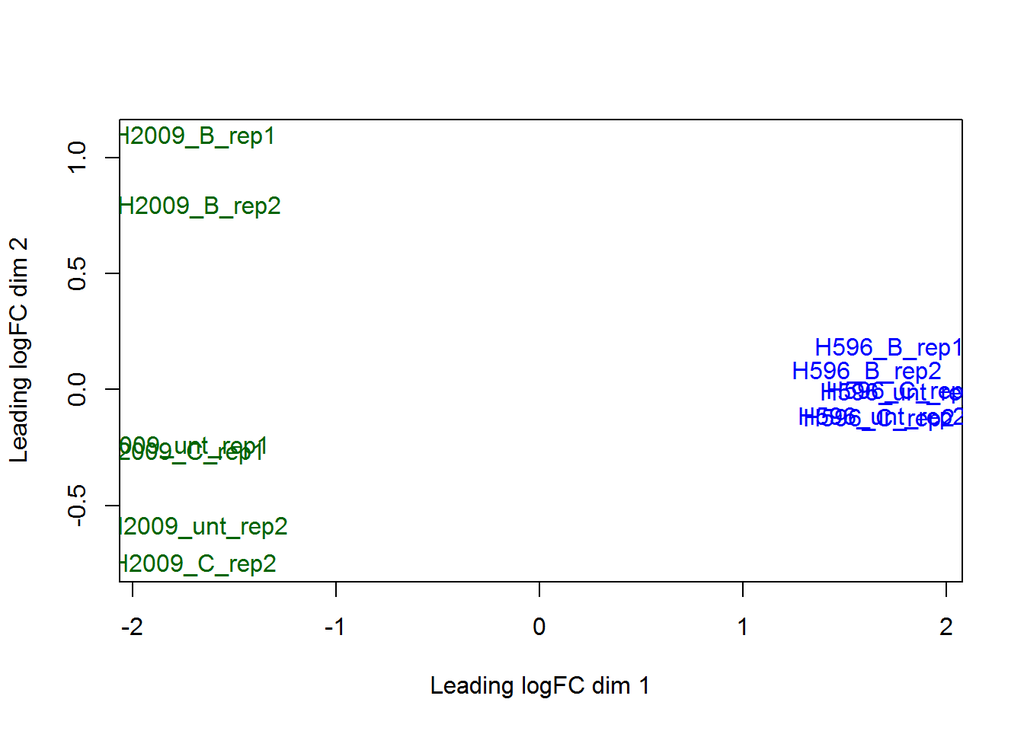

```r
d = DGEList(counts=filtered_data_matrix, group=samples$cell_type)
# Calculate the normalization factors
d = calcNormFactors(d)
#get the normalized data
normalized_counts <- cpm(d)
counts_density <- apply(log2(normalized_counts), 2, density)

# A MDS plot represents the distances between samples
plotMDS(d, labels=rownames(samples),
  col = c("darkgreen","blue")[factor(samples$cell_type)])
```

```r
#estimate common and tagwise dispersion
model_design <- model.matrix(~samples$cell_type + samples$inhibition+0)
d <- estimateDisp(d, model_design)
head(d)
```

```
## An object of class "DGEList"
## $counts
##        H2009_B_rep1 H2009_B_rep2 H2009_C_rep1 H2009_C_rep2 H2009_unt_rep1
## A1BG      0.6337900    0.4464610     0.988387     1.002820       0.733609
## A4GALT    0.4215320    0.4413510     0.802301     0.472947       0.611490
## AAAS     12.5825000   11.3534000    22.733500    19.317000      26.988900
## AACS     14.3082000   13.5831000    12.559400    11.342800      14.087200
## AACSP1    4.7945200    3.6717700     3.185890     2.254310       2.855540
## AADAC     0.0560609    0.0403119     0.000000     0.000000       0.000000
##        H2009_unt_rep2 H596_B_rep1 H596_B_rep2 H596_C_rep1 H596_C_rep2
## A1BG         0.530270   0.4246470   0.1983940    0.195514     0.25797
## A4GALT       0.415931   5.7221500   2.5450700    5.738480     3.81215
## AAAS        19.423800  16.8227000  11.2201000   20.605600    15.06750
## AACS        12.498000   7.0465000   7.2469000    7.676190     9.58913
## AACSP1       2.167740   0.0181301   0.0130291    0.000000     0.00000
## AADAC        0.000000   3.0546300   5.0063000    1.366600     2.37658
##        H596_unt_rep1 H596_unt_rep2
## A1BG        0.233709      0.152563
## A4GALT      6.852650      3.420640
## AAAS       20.032600     13.941800
## AACS        7.577460      8.786660
## AACSP1      0.000000      0.000000
## AADAC       2.003490      3.173600
##
## $samples
##                group lib.size norm.factors
## H2009_B_rep1   H2009 525616.3    1.1316424
## H2009_B_rep2   H2009 503638.1    1.0456010
## H2009_C_rep1   H2009 573685.6    1.0335974
## H2009_C_rep2   H2009 749008.6    0.7321949
## H2009_unt_rep1 H2009 632482.3    0.9347464
## 7 more rows ...
##
## $design
##   samples$cell_typeH2009 samples$cell_typeH596 samples$inhibitionC
## 1                      1                     0                   0
## 2                      1                     0                   0
## 3                      1                     0                   1
## 4                      1                     0                   1
## 5                      1                     0                   0
```

[output cut: 18 more lines]

```
##
## $AveLogCPM
## [1] 2.090970 2.978178 5.063719 4.428686 2.620365 2.552878
##
## $trend.method
## [1] "locfit"
##
## $prior.df
## [1] 4.19526
##
## $prior.n
## [1] 0.5244075
##
## $span
## [1] 0.2960669
```

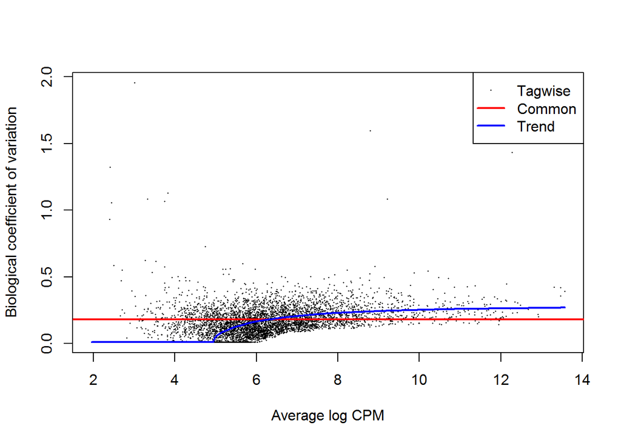

```r
# Graphing the BCV
plotBCV(d,col.tagwise = "black",col.common = "red")
```

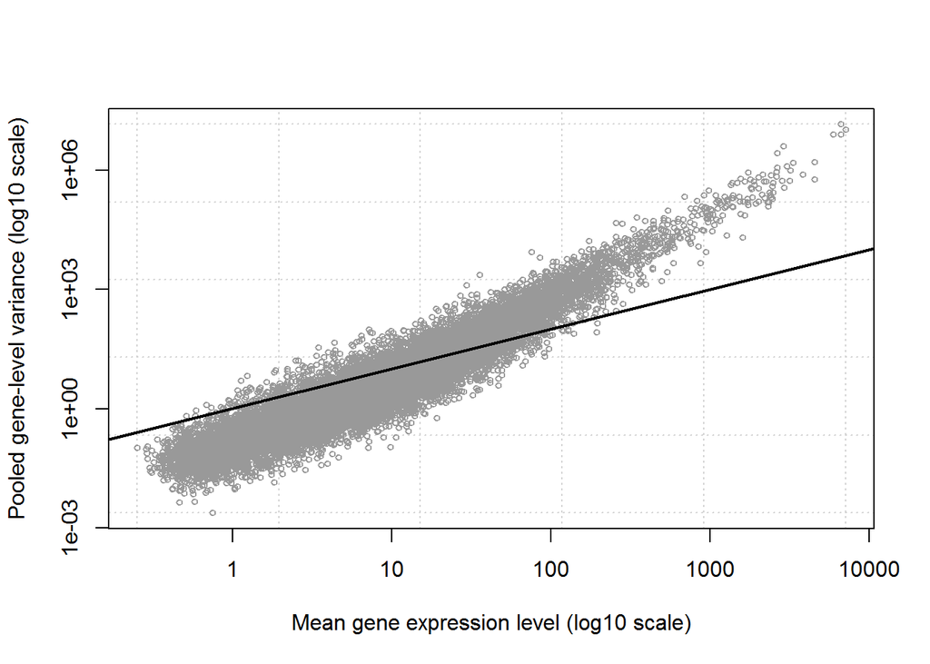

```r
# Create a visual representation of the mean-variance relationship
plotMeanVar(d, show.raw.vars = TRUE,
            show.tagwise.vars=FALSE, NBline=FALSE,
            show.ave.raw.vars = FALSE,show.binned.common.disp.vars = FALSE)
```

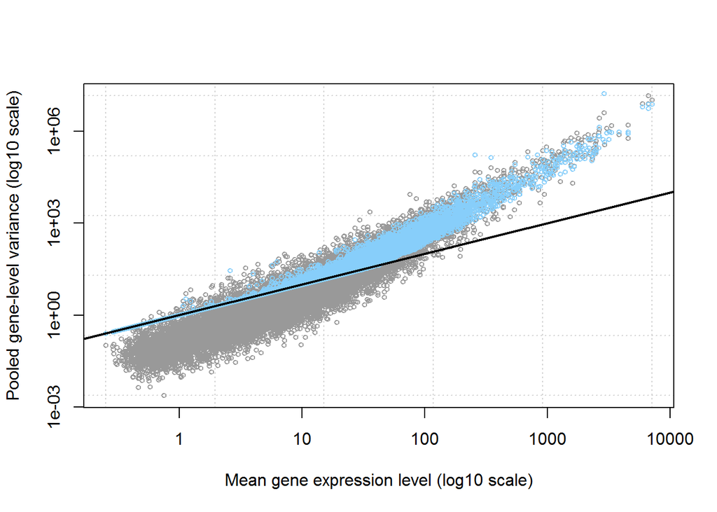

```r
plotMeanVar(d, show.raw.vars = TRUE,show.tagwise.vars=TRUE,
            NBline=FALSE, show.ave.raw.vars = FALSE,
            show.binned.common.disp.vars = FALSE)
```

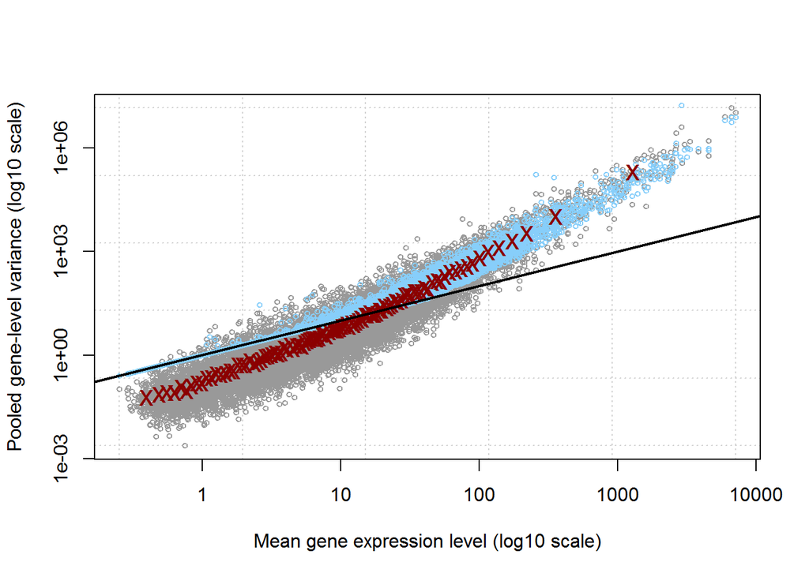

```r
plotMeanVar(d, show.raw.vars = TRUE, show.tagwise.vars=TRUE,
            show.ave.raw.vars = TRUE,NBline=FALSE,
            show.binned.common.disp.vars = FALSE)
```

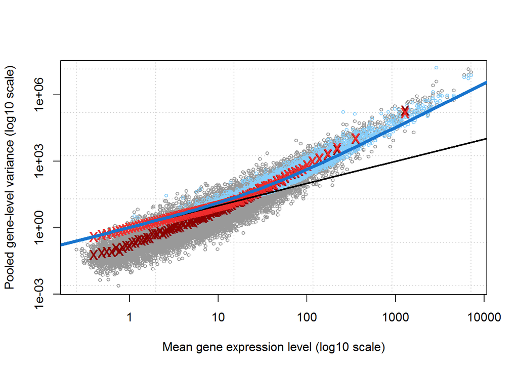

```r
plotMeanVar(d, show.raw.vars = TRUE, show.tagwise.vars=TRUE,
            show.ave.raw.vars = TRUE,  NBline=FALSE,
            show.binned.common.disp.vars = TRUE)

plotMeanVar(d, show.raw.vars = TRUE, show.tagwise.vars=TRUE,
            show.ave.raw.vars = TRUE, NBline=TRUE,
            show.binned.common.disp.vars = TRUE)
```

[output not shown]

```r
listMarts()
```

```
##                biomart               version
## 1 ENSEMBL_MART_ENSEMBL      Ensembl Genes 99
## 2   ENSEMBL_MART_MOUSE      Mouse strains 99
## 3     ENSEMBL_MART_SNP  Ensembl Variation 99
## 4 ENSEMBL_MART_FUNCGEN Ensembl Regulation 99
```

```r
listEnsemblArchives()[1:10,]
```

```
##              name     date                                url version
## 1  Ensembl GRCh37 Feb 2014          http://grch37.ensembl.org  GRCh37
## 2      Ensembl 99 Jan 2020 http://jan2020.archive.ensembl.org      99
## 3      Ensembl 98 Sep 2019 http://sep2019.archive.ensembl.org      98
## 4      Ensembl 97 Jul 2019 http://jul2019.archive.ensembl.org      97
## 5      Ensembl 96 Apr 2019 http://apr2019.archive.ensembl.org      96
## 6      Ensembl 95 Jan 2019 http://jan2019.archive.ensembl.org      95
## 7      Ensembl 94 Oct 2018 http://oct2018.archive.ensembl.org      94
## 8      Ensembl 93 Jul 2018 http://jul2018.archive.ensembl.org      93
## 9      Ensembl 92 Apr 2018 http://apr2018.archive.ensembl.org      92
## 10     Ensembl 91 Dec 2017 http://dec2017.archive.ensembl.org      91
##    current_release
## 1
## 2                *
## 3
## 4
## 5
## 6
## 7
## 8
## 9
## 10
```

```r
#Connect to the desired mart
ensembl <- useMart("ensembl")
#Get the set of datasets available
datasets <- listDatasets(ensembl)


ensembl = useDataset("hsapiens_gene_ensembl",mart=ensembl)
dim(listFilters(ensembl))
```

```
## [1] 434   2
```

```r
# filter the human related data
biomart_human_filters <- listFilters(ensembl)

# HGNC symbols to Human Ensembl Gene Ids
conversion_stash <- "ca_id_add_conversion.rds"
if(file.exists(conversion_stash)){
ca_id_add_conversion <- readRDS(conversion_stash)
} else {
ca_id_add_conversion <- getBM(attributes = c("hgnc_symbol","ensembl_gene_id"),
filters = c("hgnc_symbol"),
values = ca_exp_filtered$Gene,
mart = ensembl)
saveRDS(ca_id_add_conversion, conversion_stash)
}
```

[output not shown]

```r
# merge our new identifiers.
normalized_counts_annot <- merge(ca_id_add_conversion,normalized_counts,by.x = 1, by.y = 0, all.y=TRUE)
head(normalized_counts_annot)
```

```
##   hgnc_symbol ensembl_gene_id H2009_B_rep1 H2009_B_rep2 H2009_C_rep1
## 1        A1BG ENSG00000121410   1.06553398   0.84781088     1.666870
## 2      A4GALT ENSG00000128274   0.70868375   0.83810720     1.353044
## 3        AAAS ENSG00000094914  21.15382281  21.55963460    38.339011
## 4        AACS ENSG00000081760  24.05508663  25.79374220    21.180855
## 5      AACSP1 ENSG00000250420   8.06059420   6.97253858     5.372858
## 6       AADAC ENSG00000114771   0.09425014   0.07655062     0.000000
##   H2009_C_rep2 H2009_unt_rep1 H2009_unt_rep2 H596_B_rep1 H596_B_rep2
## 1    1.8285611       1.240859      0.9878434  0.68893561  0.35133719
## 2    0.8623806       1.034302      0.7748405  9.28345871  4.50708055
## 3   35.2229851      45.650233     36.1847215 27.29268558 19.86974602
## 4   20.6826772      23.827720     23.2826043 11.43204771 12.83358102
## 5    4.1105517       4.829988      4.0382967  0.02941378  0.02307332
## 6    0.0000000       0.000000      0.0000000  4.95574766  8.86568832
##   H596_C_rep1 H596_C_rep2 H596_unt_rep1 H596_unt_rep2
## 1   0.3152476   0.4401849     0.3757349     0.2562453
## 2   9.2527490   6.5048289    11.0170338     5.7453189
## 3  33.2245551  25.7102971    32.2064939    23.4166959
## 4  12.3771207  16.3623283    12.1823138    14.7581048
## 5   0.0000000   0.0000000     0.0000000     0.0000000
## 6   2.2035115   4.0552565     3.2210192     5.3303896
```

```r
# find the mismatching gene
ensembl_id_missing_gene <- normalized_counts_annot$hgnc_symbol[
which(is.na(normalized_counts_annot$ensembl_gene_id))]
head(ensembl_id_missing_gene)
```

```
## [1] "AAED1"  "AARS"   "ACN9"   "ADCK3"  "ADCK4"  "ADRBK1"
```

```r
length(ensembl_id_missing_gene)
```

```
## [1] 1126
```

```r
old_mapping <- merge(ca_exp[,1:13],data.frame(ensembl_id_missing_gene),all.y = TRUE, by.x=1, by.y=1)
head(old_mapping)
```

```
##     Gene H2009_B_rep1 H2009_B_rep2 H2009_C_rep1 H2009_C_rep2 H2009_unt_rep1
## 1  AAED1      7.24570      3.70000      9.56498      7.78786        9.92559
## 2   AARS     24.25830     31.40230     55.34730     54.31640       55.78710
## 3   ACN9     10.42580     13.92670     12.04180     35.01710       13.84100
## 4  ADCK3      7.17282      5.58259      6.44101      4.63051        6.75068
## 5  ADCK4      5.81712      5.74872      4.45032      3.74066        5.49316
## 6 ADRBK1     21.65840     15.08520     17.66770      9.95300       18.48660
##   H2009_unt_rep2 H596_B_rep1 H596_B_rep2 H596_C_rep1 H596_C_rep2 H596_unt_rep1
## 1        6.37736     6.66025     4.05354     7.46406     5.69294       8.06291
## 2       67.18420    44.64900    42.66920    50.37830    52.14140      52.49900
## 3       22.04660    15.47520    25.29510    13.82910    20.85210      13.58290
## 4        4.43125     6.44729     5.28348     5.53648     5.15139       6.48985
## 5        3.60603     8.84739     5.60508     8.33786     7.17732       8.84690
## 6        9.94045    25.62100    15.41290    20.99680    18.43610      22.45990
##   H596_unt_rep2
## 1       6.32458
## 2      49.51820
## 3      23.64390
## 4       4.61952
## 5       5.78687
## 6      16.08950
```